# Bataan Operations for GuangQiang, Medics, & FCF Corporation

Alexia Isabel Cortes

November 28, 2017

# WHAT IS AFAB?

According to investphilippines’ website, “The Authority of the Freeport Area of Bataan (AFAB) is a government owned and controlled corporation that was created by virtue of Republic Act 9728 or the ‘FAB Act of 2009.’ The Freeport Area of Bataan (FAB) is located in Mariveles, Bataan and it is strategically located between the Manila Bay and the South China Sea. The FAB used to be the former Bataan Export Processing Zone, the first economic zone in the Philippines.” During the conference in the Freeport Area of Bataan building it was told to us by the speaker that Bataan has the fastest growth rate when it comes it employment and investment since it is just near Manila Bay, where massive ships can easily dock in the area to ship and transport products from one place to another that is why there are several corporations, manufacturing, and companies that are situated in Bataan.

According to Bataan’s Government website, “Many of the Philippine’s top & most successful companies across a range of industry sectors already established operations in Bataan, such as Petron Bataan Refinery, TOTAL Petroleum, Liquigaz, UniOil, San Miguel Corporation Feed Mill, Bataan 2020, ATI Grains Terminal, Diversified Plastic Film Systems, Inc., Philippine Resins Industries, Inc., NPC Alliance Corporation, Phoenix Polypropylene Plant, and international companies like Orica Explosives, Charoen Pokphand Foods Phils and the Maritime Academy of Asia and the Pacific (MAAP), the most modern maritime academy in the Philippines.” Many of the reasons why local and multinational companies chose to invest in Bataan is because of the success it brings when it comes to economics and trading. During the conference the speaker told us three things why you should invest in Bataan. First thing is the High Quality of Living can be fully experienced in Bataan since it is not much overpopulated unlike Manila and it is near Manila Bay where most of the business occurs. Second thing is A peaceful and secured location, the place is almost in a remote area but it still considered to be safe since Bataan is a province there are no busy streets and noisy people that can be seen but just the nature which you can fully appreciate once you are in Bataan. The third thing is It is Home to the fastest growing Freeport zone in the country, According to Louella Desiderio’s article named Bataan Freeport is fastest growing Freeport zone in Phl, “In 2012 and 2013, the FAB was recognized as the fastest growing freeport in the country by the National Statistical Coordination Board. Since the AFAB took over operations from the Bataan Export Processing Zone, the number of locators has jumped nearly 236 percent to 92 in August of this year from 39 in 2010.”

During the conference they have also stated the different reasons on why you should invest in the Philippines. First one is, it is recognized as one of the ideal investment locations. According to Wilson Lee Flores’ article named Why foreign and local entrepreneurs should invest in the Philippines now, “Lower taxes on business and personal incomes. Right now, we have among the highest business and personal income tax rates in the region. Reforms to lower these high tax rates will not only boost the attractiveness of doing business in the Philippines for foreign and local investors, it will free up more disposable income among the citizenry and thus boost our consumer spending. I encourage foreign and local investors to already position themselves here in the Philippines, to start businesses or expand before this renewed economic boom.” This is why majority of companies are choosing to do their business here in the Philippines because of the wide variety of benefits and advantages they get to receive considering we are offering lower costs when it comes to labor. Second one is Availability of Skilled and World-Class Workforce, we know that Philippines offers a vocational education and training to majority of the workers and that is TESDA which stands for Technical Education and Skills Development Authority, that is why we have a huge number of workers who are fully skilled in industry and manufacturing sectors of the business since this kind of job offers high salaries and wages. According to DOLE’s article named TESDA produces 937,000 skilled Filipinos for local, overseas labor markets, “A preliminary report of TESDA Director General Augusto Syjuco, Jr. to Sto. Tomas showed that the TESDA-led technical education (TVET) sector produced some 937,000 trained workers from January to November this year to supply labor market requirements locally and overseas particularly on”in-demand" skills in the areas of information and communications technology (ICT), tourism, and agri-fishery.” Third one is Profit improvement due to Low Cost of Doing Business, there are different type of costs that are considered to be low or below average here in the Philippines that is why businesses are lured to establish their business here so that they can maximize their profit. Labor cost are one of the factors that are viewed by businessmen since it is specially low here in the Philippines. According to Staples’ article named Importance of Labor Cost Reduction for Small Businesses Explained, ‘The price of labor constitutes a significant part of the total cost of a small business, and no business can survive for long by ignoring labor costs. Downsizing the workforce may result in short-term cost reduction. However, this will leave you vulnerable when you need to ramp up volumes with short notice. Unfavorable employee turnover also contributes to overall labor costs. Rational and intelligent labor cost control will boost productivity and enhance profits.”

Now we have a better understanding of the Authority of the Freeport Area of Bataan but we must also know the vision they state According to the website of AFAB, “The FAB vision is to be the freeport of choice in the country by 2020, becoming a center of trade, innovation and sustainable development in Asia promoting work-life balance and global competitiveness.”

# GUANGQIANG MANUFACTURING CORP.

## INTRODUCTION

GuangQiang is a company located in Phase 1 7th Street, Freeport Area of Bataan, Mariveles 2016 that manufactures and produces mould and fitted materials for Shoe Factory and Handbag Factory they also provide material supply like non-woven fabric, fiber paper, bonded leather, bontex, and lining fabric etc. They supply to companies and factories around Bataan Area like Coach, Tory Burch, Michael Kors, etc.

The warehouse in Bataan showed to have a poor working environment as there are scraps of materials and liquids on the ground that is scattered on the floor, there are also no proper safety uniforms and equipments to be observed by the workers as they work on the production. Only one of the supervisor in the warehouse can speak English fluently since their nationality is Chinese, which could affect the communications between the workers and top managers or supervisors as there could be a possibility that a misunderstanding will occur in future situations.

## VALUE CHAIN

What is a Value Chain? According to Tara Schofield’s article named What Is a Value Chain? – Definition, Analysis & Example, “A value chain is a way to look at two different types of business activities: the first action that creates value for a customer and the following action that supports the execution of the first action.” It is important for a business to determine and study their value chain since this will be a way to dissect the processes the business go through and how it can affect the final outcome of the product or service to the customer.

The second part of the value chain is Operations. According to BusinessDictionary, “Operations transform resource or data inputs into desired goods, services, or results, and create and deliver value to the customers.” I will express that this is the core of the value chain for me since this is where the birth of the product or service takes place, this is where you combine pieces of raw materials and goods in order to produce a product that will be introduced soon to the market. This is critical for the existence of the product or service since this is where you will be able to fully grasp a physical value to the good. Operations should be handled properly and strictly since this is where all the transformation processes come from, it is vital for a company to have a stable operation in order to improve on the other steps of the value chain. There are four departments responsible in manufacturing the mould and fitted materials and that are the Cutting, Molding, Welding, and Refining. These processes are assisted by machineries and labor work since the final product should be accurate and precise since these are patterns needed by shoe factories and handbag factories in making their product.

The third part of the value chain is Outbound Logistics. According to Jerad Dowler’s article named What is Outbound Logistics?, “Outbound logistics refers to the processes involved in the movement and storage of products and how related information flows from the end of the production line to the firm’s customer.” Storaging of the finished products is also important as this is where we maintain the value of the product or service. GuangQiang storages their fabrics right at the entrance of the factory, it has a poor location for the fabrics to be stored since some parts of the floor are wet and it could affect the quality of the fabric.

The fourth part of the value chain is Marketing and Sales. According to Kayla Harrison’s article named What is a Value Chain Analysis, “Marketing and sales involves advertising, promotions, sales-force organization, distribution channels, pricing and managing the final product to ensure it is targeted to the appropriate consumer groups.” This is where you create relationships with your potential target customers since you need to fully understand their behavior and decisions when it comes to purchasing a product or service. A company should be able to catch the attention of the customers when it comes to promoting the product, giving out full information makes the customers accustomed the advantages and benefits they will be receiving when they purchase the product. GuangQiang only distributes their final products to companies and factories within Bataan, they also have another factory that is locaed in Subic, Clark. The company is looking for a merchandiser to market their available products, they posted this information in the website of Authority of the Freeport Area of Bataan.

The fifth part of the value chain is Service. According to Kayla Harrison’s same article stated above, “Service refers to the activities needed to maintain the product’s performance after it has been produced, and includes things like installation, training, maintenance, repair, warranty and after-sale services.” Some companies do not offer service to their customers, which can possibly result for a business to go downhill, offering value does not stop once a customer got a hold of the product but it continues to show value as long as the product itself exists. This is where customers can truly see if a company has a good relationship with them since they will feel important if a business expresses care and understanding through their assistance after service.

## PROCESSES

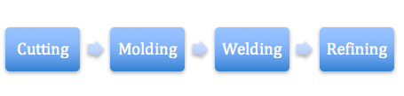

GuangQiang Processes.

Cutting, Molding, Welding, and Refining are the four departments in the process of manufacturing mould and fitted materials in GuangQiang. The Cutting Department is responsible for following the requests of the customers in terms of measurements in their desired pattern, cutting is done with the use of Metal Cutter. The Molding Department will assess the cutted metal to mold them to be transformed into patterns. The Welding Department is responsible for attaching the different metals together in order to make the final outcome of the product. Refining is the last department in the production process where they remove unnecessary parts and materials in the final product in order to deliver a good quality mould and fitted materials.

## EQUIPMENT

A variety of different machineries and equipment can be seen once you have entered the factory of GuangQiang Manufacturing Corp. It makes the processes flow much more easier and smoother since these type of machines are precise and accurate in doing their work but leaving it alone to work would not be sufficient to the company since there is also a probability that it can produce defective products, so in order to solve for that, a labor work is needed to control and assist the machine in production.

Metal Cutter, Slush Cutter, Welding Machine, and Tesla Laser are the equipments GuangQiang uses in their everyday operations in production. Metal Cutter serves to be the one to be used for cutting desired patterns requested by the customers in a metal. Slush Cutter is the one responsible in forming the shape of a product during the moulding process. Welding Machine is used so to heat the metals to the point where you can bend it and join it with other parts of metals to fully form a pattern. The Tesla Laser is used for lettering and designing the product. The laser is very detailed as it is considered to be the last machine in the production process.

## HUMAN CAPITAL REQUIREMENTS

In the recent part we have talked about equipments that the company uses in production and operations but human capital is also an important aspect of the business. In this century, human capital is considered to be much more prone to mistakes and unimportant in a business ever since the technology paved in the industry as it is more accurate and faster but human capital still contributes a lot in an industry. According to Harvard Business School’s article named Why human capital is your company’s greatest asset, “More than ever before, firms and institutions must recognize the importance of human capital as a critical first step in tapping into unrecognized potential. Executive education is an investment in that capital, a way to unlock that untapped talent. What companies get in return is better leaders, more effective managers, better decisions, and a greater return on investment.”

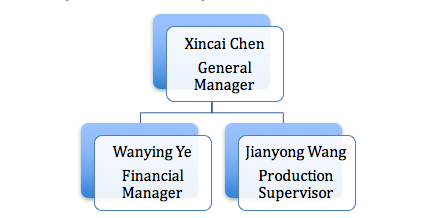

GuangQiang Human Capital Requirements.

The figure above shows the managers situated in the Philippines for GuangQiang Manufacturing Corporation. The General Manager is responsible for the overall operation and management of the corportation. The Financial Manager is responsible for the financial needs of the corporation for cash inflows and outflows. The Production Supervisor is responsible for checking the production process over time if it is going smoothly.

GuangQiang doesn’t require their workers to train since they informed us that the work to be done can be easily taught to new workers. The company provides job opportunities to several Filipino workers, they have posted the requirements needed for a suitable worker in the website of Authority of the Freeport Area of Bataan. A Metal Mould Bender requires a female worker that should be at least 18 years old and above. A CNC/Lathe Machine Helper requires a Male or Female worker that should be at least 18 years old and above. A CNC Machine Operator requires a male worker that should be at least 18 years old and above, a college graduate with any course that should be related to the work. An Auto CAD Operator requires a male that should be at least 18 years old and above that should be a college graduate who is professional in using AutoCAD. A Blade/Wire Cutting Operator requires a male worker that should be at least 18 years old and above with 6 months to 1 year work experience. A Welder requires a male worker that should be 18 years old and above, a graduate of any vocational course, and with a 6 months to 1 year of relevant work experience. A merchandiser requires a male or female worker that should be at least 18 years old and above, a college graduate, and knows how to speak Chinese, English, and Tagalog. A translator is needed for GuangQiang since the managers are not fluent in speaking English and Tagalog when we interviewed one of the supervisors present in the factory, for this job it requires a male worker that should be at least 18 years old and above, at least college level, with 1 to 2 years of work experience related to the field work, and can speak, read, and write in Chinese and English. A Helper requires a male worker that should be at least 18 to 30 years old, and at least a high school graduate. A Merchandiser requires a male worker that should be at least 20 to 30 years old, a college graduate of any course, and with at least 6 months of work experience.

# MEDTECS INTERNATIONAL CORPORATION LIMITED

## INTRODUCTION

According to Medtecs’ website in the About Us page, “Medtecs International Corporation Limited (the ‘Company’) is a well-known healthcare products and services provider and a leading manufacturer of medical consumables. The Company and its subsidiaries (collectively, the ‘Group’) commenced operations in the Philippines in 1989.” Medtecs offers dyeing, bleaching services, manufacture of protective clothing & uniforms, medical specialty garments according to the Authority of the Freeport Area of Bataan Directory.

Medtecs facility also appears to have a huge facility but the working environment is quite uncomfortable for the workers because of the humidity inside caused by the hot weather, there are also liquids that can be seen on the ground in the dyeing department, which is unsanitary. The workers are fully informed in their field of work as they have all answered the queries we asked regarding about operations and manufacturing.

## VALUE CHAIN

The first part of the value chain is Inbound Logistics. Medtecs get their raw materials in Taiwan where they first check the quality of the materials if it is good enough to enter the operations process.

The second part of the value chain is Operations. The operation of the company is 24 hours that is divided with 3 hours shift with a total of 8 hours per shift. Sometimes there is a need for the workers to overtime to meet the demanded quota of their customers. There are times when they have defective or excess fabrics and what they to do with this situation is that they try to sell this excess to the market in order to minimize waste.

The third part of the value chain is Outbound Logistics. Majority of their customers are from Manila, specifically Divisoria, which has an estimated travel time of 2 to 3 hours. In terms of exporting their final products internationally they export it to USA, Taiwan, and Cambodia, which only happens once or twice a month.

The fourth part of the value chain is Marketing and Sales. When we visited the FAB Trade Fair, Medtecs was present in the fair where they sell their product lines to the open market at a discounted price. In terms of production, they follow their customer’s special request for the desired outlook of the fabric and the desired shipment that is why sometimes workers are requested to overtime to meet the demanded quota.

The fifth part of the value chain is Service. Almost all of the companies does an after service care to their customers to make them know that satisfaction of the customer is the number one priority of a business. This is where they will be receiving feedbacks and through this they will be able to know on where they excel and where they should improve.

## PROCESSES

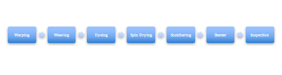

Medtecs Processes.

The first department of the production process is Warping, where yarns are arranged properly in order to make a fabric or cloth. Female workers are the ones responsible for warping the yarn manually so it takes a massive amount of time to finish in this department. I consider this department to be very complicated since it requires a lot of patience in sectioning the yarns to warp.

The second department of the production process is Weaving, this is where you create the fabric product and serves as the final stage in creating the cloth. This department relies heavily on machinery to make the process fast but labor is still needed to operate and assist the machine and to watch over the process. The third department of the production process is Dyeing, the fabrics are dyed according to the color preference of their customers

The fourth department of the production process is Spin Drying, this is where the fabric is thoroughly cleanse in order to remove unnecessary particles and to remove the excess dye to balance out the colors among the fabric.

The fifth department of the production process is Scutchering, after the fabrics have been taken out the spin dryer the next step is to warm up the fabrics in order to stretch it out and through the Scutchering Department we would be able to heat the spread out fabric in a machinery.

The sixth department of the production process is Stenter, in this process is where the fabric is dried and heated out once again to maintain the quality of the fabric, it also gets the required width, weight, and the finishing touch of the fabric. There are special processes involved in this department to ensure that Medtecs can deliver high quality fabrics to their customers.

The seventh department of the production process is Inspection, this serves as the last department for manufacturing a fabric. Before the fabric is to be shipped out, they check if they have met the desired demand and expectations made by the customers and see if there are fabrics that turned out to be defective. Peaching, Double Folding, and Winding is done under this department. Peaching is responsible for making the fabric soft but it does not apply to all kinds of fabric – this is a special process for sanding. Double Folding is a packaging process, wherein the fabric is for double fold. Winding is also in the packaging process where the fabrics is designed for long fold. These three processes are an important aspect of the production process as it enables for rechecking and refining of the product in order to ensure that there are no defective products that will be delivered to the consumers.

## EQUIPMENT

There are different kinds and types of machineries available in the factory when it comes to production process as they make the work much easier and faster than labor work. Some departments in production requires mostly manual labor work like the Weaving department since every female worker separates the threads by hand and insert them in a loop. The employees are properly trained for only three days to handle and manage the equipment since it is not hard to operate considering that it is automatic, the worker should only just be able to power it and let it do the work.

I have observed that it is only in the Warping and Weaving Departments where women are present in the workplace, we have asked some of the workers who are from the dyeing if why there are no female workers in this department and they have said that some female workers used to work in the in this department but they were replaced by male workers since they do the work much faster and easier since they understand more how a machinery and equipment works. They transported the female workers where they do not need to exert much more effort.

## HUMAN CAPITAL REQUIREMENTS

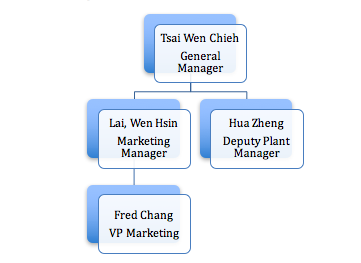

Medtecs Human Capital Requirements.

The figure above shows the managers situated in the Philippines for Medtecs International Corporation Limited. The General Manager is responsible for the overall management of the corporation. The Marketing Manager is responsible for delivering and introducing the product to the customers. The Deputy Plant Manager is the second in command in plant and factories.

There are proper training given to the employees of Medtecs but the training can be done completely under 3 days since majority of the operation and production process are done with the use of automatic machineries. The employees are only trained on how to fully operate the machinery. The company provides job opportunities to several Filipino workers, they have posted the requirements needed for a suitable worker in the website of Authority of the Freeport Area of Bataan like a Marketing Assistant that requires a male or female worker that should be at least 18 years old and above, a college graduate of any course, and has a 1 to 2 year work experience.

# FCF MANUFACTURING CORPORATION

## INTRODUCTION

FCF Manufacturing Corp. is a China-based company that manufactures bags solely for Coach. According to Rappler’s article called Made in the Philippines: more Coach bags, “FCF’s Bataan plant would the second Coach factory after Luen Thai, which already has a presence in garments manufacturing in the Philippines through its manufacturing facility for Coach bags in Tarlac.” The manufactured product, Coach, is considered to be one of the known luxury bags in the world, according to the same article, “Coach is the leading American marketer of luxury lifestyle handbags and other fashion accessories and competes with premium apparel and accessories players like Polo Ralph Lauren’s, Liz Claiborne and AnnTaylor.”

Once we have entered the facility, everyone was in awe on how huge it is and how there are a wide number of employees working in different departments who follows a safety and precautionary uniforms which they used for the production process. The working environment is very good since the facilities are provided with air conditions so that workers can find it comfortable to work, it also appears that the workplace is organized since there are proper placements for workers, raw materials, machineries, inventories, and so on.

## VALUE CHAIN

The first part of the value chain is Inbound Logistics, FCF get their raw materials like the fabrics and leather from Italy since the company, Coach, wants the best and high quality materials to be used in the production process so that the final product can come out perfect. The leather have been stored in a special storage in the warehouse where the place is airconditioned since the temperature can greatly affect the leather’s texture that is why they need to monitor the temperature just to maintain the right quality of the raw materials. The different typees of leathers are divided and placed in different compartments with proper labels in an organized manner.

The third part of the value chain is Outbound Logistics, after the production of the final goods it is then transferred to Outbound Logistics where it will be stored and be available for distribution and shipment to the various Coach bags industries in different parts of the world. Coach is still strict when it comes to the distribution process since we have asked one of the supervisors what will happen if incase there are products that were not shipped and they have answered that if it still stocked in the warehouse for a maximum of 3 months then they need to extinguish the product since they take pride of their quality. These bags won’t be in sale to the market and it will also not be considered as an overrun to protect maintain quality, even though this kind of rule is said to maximize the costs they need to execute this since it is under the contract of Coach to stay true to their reputable image.

The fourth part of the value chain is Marketing and Sales, the products currently being manufacture and processed inside the factory should be out in the market in under two months time. These are new concepts, lines, and designs for the Coach bags that will be exported to different Coach bags industries in different parts of the world to be sold in stores. Unfortunately, the Philippines do not get to be distributed since there are selected locations and places FCF can distribute the final products to.

The fifth part of the value chain is Service, Coach offers warranty to their customers to ensure them that if such problems are to be met they can quickly assist them in managing and fixing the said problem as they value their customers even after the purchasing process. The employees and workers are given out full information about the product

## PROCESSES

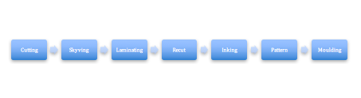

FCF Processes.

Cutting, Skyving, Laminating, Recut, Inking, Pattern, and Moulding are the seven departments in the process for manufacturing high quality luxurious bags.

The first department of the production process is Cutting, this is where the fabrics and leathers were cut by using the guide pattern of the design of the handbag. Precise measurement must be observed in this department since if there is inaccuracy it might result to a defective product, which might be a big loss for the product since the quality of the fabrics are high and imported from other countries.

The second department of the production process is Skyving, this is where the leather are cut into thin pieces so that they will be ready to be placed inside the bag. This is done by using the Diecut machine.

The third department of the production process is Laminating, this is where the leather is glued to some material, this serves to be a protection for the leather. This process makes the leather stretchable and form shapes in your desired design and preference.

The fourth department of the production process is Recut, this department is done with the assistance of the machinery. This is where the proper allocation of the raw materials, specifically, the leather takes place since this fabric is known to be high in cost because of its durability, texture, and quality.

The fifth department of the production process is Inking, this is done manually by workers with the use of their hands. They hold a pointed tip stick that is dipped in an ink to coat the edges of the leather to protect them from being damaged. An employee should have a steady hand since this should be done in a fast and accurate manner, it also requires patience since it is not an easy job to do for it is not assisted by a machinery but it is solely pure manual labor work.

The sixth department of the production process is Pattern.

The seventh department of the production process is Moulding.

## EQUIPMENT

There are different kinds of machineries and equipments present in the factory such as the machines responsible for cutting the leathers and fabrics into their desired patterns by using an accurate and measured stencil patterns. There are also machines that are responsible in combining pieces of fabrics and leathers. Machines that are responsible for stamping the signature Coach brand into the leather.

The machineries and equipments are maintained properly since the operations are strict, the maintenance should also be strict since these are important aspects during the production process of bags. Employees are given enough information on how they can operate and manage equipment

## HUMAN CAPITAL REQUIREMENTS

FCF currently handles manufacturing 48 production lines, in order to produce all of these lines a total number of 70 to 90 workers are assigned to each line to fulfill the production process of each. The employees are given a 2 shifts a day, a total of 1 hour lunch break, and 15 minute break where most of the employees choose to sleep because of the hectic production process they have done.

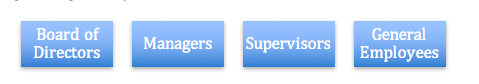

FCF Human Capital Requirements.

FCF gives importance to their employees since they are required to undergo training before they can fully work in the company. There is a location for the different employees to be trained. The reason why they need to undergo training is because Coach sets high standards for their products during the production process in order to have a high quality final product since they are one of the known sellers and distributors of luxurious bags around the world.

The company provides job opportunities to several Filipino workers, they have posted the requirements needed for a suitable worker in the website of Authority of the Freeport Area of Bataan like Cutting Operators, High Head Machine Operator, Quality Controller, Table Works, and Skilled Sewer that all requires experience since this will be an advantage for hiring.

# BIBLIOGRAPHY

GuangQiang Manufacturing. (n.d.). Retrieved from http://www.yellow-pages.ph/business/guangqiang-manufacturing-corporation

Schofield, T. What Is a Value Chain? – Definition, Analysis & Example. (n.d.). Retrieved from https://study.com/academy/lesson/what-is-a-value-chain-definition-analysis-example.html

Mind Tools Content Team. Porter’s Value Chain: Understanding How Value Is Created Within Organization. (n.d.). Retrieved from https://www.mindtools.com/pages/article/newSTR_66.htm

Trade Finance Global. What are Inbound Logistics?. (n.d.). Retrieved from https://www.tradefinanceglobal.com/services/shipping-transport/inbound-logistics-definition/

Operations. (n.d.). Retrieved from http://www.businessdictionary.com/definition/operations.html

Dowler, J. What Is Outbound Logistics?. (2015, May 26). Retrieved from http://www.paragon-u.com/what-is-outbound-logistics

Harrison, K. What is a Value Chain Analysis. (2017, November 17). Retrieved from https://www.businessnewsdaily.com/5678-value-chain-analysis.html

Corporate Profile. (n.d.). Retrieved from http://www.medtecs.com/

Made in the Philippines: more Coach bags. (2012, May 27). Retrieved from https://www.rappler.com/business/6018-made-in-the-philippines-more-coach-bags

Harvard Business School. Why human capital is your company’s greatest asset. (n.d.). Retrieved from https://qz.com/403391/why-human-capital-is-your-companys-greatest-asset/

GuangQiang Manufacturing Corporation. (n.d.). Retrieved from http://www.afablabor.com/job-opportunities/category/guangqiang-manufacturing-corporation

Table 4.0 AFAB (Authority of Freeport Area of Bataan) Enterprise Directory CY 2010. (n.d.). Retrieved from http://www.bataan.gov.ph/home/images/sep13/PEZA_directory_tab_6.28.pdf

Notice of Filing of Application/s for Alien Employment Permit/s (AEP/s). (n.d.). Retrieved from http://ro3.dole.gov.ph/fndr/mis/files/08-10-15.pdf

Authority of the Freeport Area of Bataan. (n.d.). Retrieved from http://investphilippines.gov.ph/incentives/authority-of-the-freeport-area-of-bataan/

Why Invest in Bataan? (n.d.). Retrieved from http://bataan.gov.ph/home/bataan-articles/1222-why-invest-in-bataan.html

Desiderio, L. (2014, October 2). Bataan Freeport is fastest growing freeport zone in Phl. Retrieved from http://www.philstar.com/business/2014/10/02/1375342/bataan-freeport-fastest-growing-freeport-zone-phl

Flores, W. (2016, August 15). Why foreign and local entrepreneurs should invest in the Philippines now. Retrieved from http://www.philstar.com/business-life/2016/08/15/1613408/why-foreign-and-local-entrepreneurs-should-invest-philippines-now

TESDA produces 937,000 skilled Filipino workers for local, overseas labor markets. (November 30). Retrieved from https://www.dole.gov.ph/news/view/15

Importance of Labor Cost Reduction for Small Businesses Explained. (n.d.). Retrieved from https://www.staples.com/sbd/cre/tech-services/explore-tips-and-advice/tech-articles/importance-of-labor-cost-reduction-for-small-businesses-explained.html

Authority of the Freeport Area of Bataan: Vision. (n.d.). Retrieved from http://afab.gov.ph/?page_id=46